### BRAIN NTNU Workshop AI 8. april 2021

# Kolonial.no Service Time Prediction

Velkommen til workshop med BRAIN NTNU og Kolonial.no!

Kolonial.no er Norges største dagligvarehandel på nett. Hos oss bestiller kundene matvarer enten i appen vår eller på nettsiden, og velger hvilken dag og hvilket tidsintervall de ønsker å få dette levert til. Deretter plukkes varene på lageret vårt, lastes på bilene våre, og blir deretter kjørt helt hjem til døra for folk over hele østlandet og deler av sørlandet hver dag.

For at vi skal kunne gjøre dette, er vi avhengig av et system for å sette sammen ruter som bilene våre kan kjøre for å levere til fleste mulig kunder til riktig tid. Dette er et såkalt "vehicle routing problem" - et ruteplanleggingsproblem. Dette har vi en løsning for i dag, men ruteplanleggeren vår blir kun så god som dataene den får for å løse problemet.

For å kunne sette opp ruter, trenger ruteplanleggeren å vite 1) hvor lang tid det tar å kjøre mellom kunde A og kunde B, og 2) hvor lang tid det tar å levere til henholdsvis kunde A og kunde B. Det er 2) vi skal jobbe med her i dag.

Når en sjåfør skal levere til en kunde og kjører inn i området i umiddelbar nærhet til denne kunden, må han eller hun først lete etter et sted å parkere, og deretter faktisk parkere. Etter dette må sjåføren inn i lasterommet på bilen, plukke frem riktig leveranse og scanne den for å verifisere dette. Når dette er gjort, må sjåføren deretter enten bære kassene fra bilen og til dørstokken til kunden, eller benytte trallen sin hvis dette er mulig. Hvis dette er en "utenfor døren"-levering, setter sjåføren bare kassene utenfor døren. Hvis det ikke er det, ringer kunden på og tilbyr seg å sette varene innenfor døren (hvis det da ikke er midt i en pandemi...). Etter at alle kassene er levert, må sjåføren tilbake til bilen, sannsynligvis rydde litt i lasterommet, og deretter sette seg i førersetet. Først da er han eller hun klar til å kjøre videre til neste kunde.

Den tiden en sjåfør bruker på å gjennomføre disse oppgavene kaller vi **servicetid**. Og hvis vi ikke har gode estimater på hvor lang servicetid vi trenger for hver enkelt leveranse, vil dette gi utslag i urealistiske ruter fra ruteplanleggeren, som igjen påvirker vår evne til å levere til flest mulig kunder til riktig tid.

*I skrivende stund tester vi i Kolonial.no ut å benytte en maskinlæringsmodell for å predikere denne servicetiden. Klarer du å gjøre det bedre?*

Dere får tilgang til et datasett som er nesten helt likt det rådatasettet vi benytter for å trene våre modeller. På dette kan dere gjøre det dere ønsker av feature engineering og benytte de metodene dere ønsker - maskinlæring eller ikke - for å lage noe som kan predikere servicetid på en hvilken som helst Kolonial.no-leveranse.

```python
# Pandas er det foretrukne verktøyet for å analysere tabellariske data i Python,
# og brukes av mer eller mindre alle som kaller seg data scientists og som har
# Python som hovedarbeidsverktøy. I notebooks kan du bruke !-notasjonen for å
# kjøre kommandoer som du ville gjort i kommandolinjen din, og her bruker vi
# dette for å installere Pandas med pip.
!pip install pandas
```

```python
from pathlib import Path

import pandas as pd

# For å lettere kunne inspisere Pandas DataFrames i notebooks, er det nyttig
# å konfigurere Pandas til å vise litt flere rader og kolonner enn standard.
pd.options.display.max_rows = 100
pd.options.display.max_columns = 100
pd.options.display.max_colwidth = 100

# Vi leser inn dataene fra CSV med Pandas. Hos oss liker vi å alltid putte dataene
# i en mappe vi kaller "artifacts", som vi holder utenfor versjonskontroll og unngår
# å blande med selve koden. Her må du endre DATA_PATH til mappen der du har lagret
# datasettet. Hvis datasettet ligger i samme mappe som notebooken din, kan du la
# DATA_PATH være tom.
DATA_PATH = "artifacts/"
deliveries = pd.read_csv(Path(DATA_PATH) / "deliveries.csv.gz", compression="gzip", low_memory=False)
```

```python
deliveries.columns.tolist()
```

```
['user_id',
 'can_select_unattended_delivery',
 'floor',
 'has_elevator',
 'can_use_trolley',
 'is_unattended_delivery',
 'delivery_date',
 'slot_start_time',
 'slot_end_time',
 'num_boxes_dry',
 'num_boxes_cold',
 'num_bags_frozen',
 'num_products',
 'products_weight',
 'street',
 'street_number',
 'zip_code',
 'zip_place',
 'area_segment',
 'municipality',
 'service_time']
```

## Beskrivelse av datasettet

Dette er et klassisk supervised learning-problem der du har en label (kolonnen **service_time**) som du skal forsøke å predikere basert på et sett med features. Disse representerer egenskaper forbundet med kunden som skal ha levering, ordren som skal leveres, leveringen i seg selv og adressen den skal leveres til.

Viktige ting å vite om datasettet:

- Datasettet representerer et begrenset utvalg av kundemassen vår.
- De unike verdiene i alle kolonner som inneholder geografisk informasjon eller annen informasjon om kunden som har fått leveringen har blitt hashet. Dette har imidlertid ingenting å si for å kunne trene modeller til å predikere servicetid, ettersom de fungerer like godt som features så lenge de unike kategoriene er beholdt.
- Servicetidene i datasettet er ikke reelle servicetider, men rangordningen i distribusjonen er beholdt (så en servicetid på 1 er høyere enn en servicetid på 0, en servicetid på 2 er høyere enn en servicetid på 1 etc.). Dette gjør at det likevel er interessant å jobbe på problemet med maskinlæring!

Kolonnene i datasettet:

- **`user_id`**: ID-en til kunden som får levering. Denne er unik per kunde, og hvis én `user_id` forekommere flere ganger i datasettet er dette ulike leveringer til den samme kunden.
- **`can_select_unattended_delivery`**: Hvorvidt denne kunden har mulighet til å velge "utenfor døren"-levering. Det er noen egenskaper ved adressen og bygget som avgjør om dette er mulig, som gjør at det kan være en interessant feature.
- **`floor`**: Hvilken etasje ordren skal leveres i, hvis boligblokk eller kontorbygg.
- **`has_elevator`**: Hvorvidt det er heis i bygget der ordren skal leveres, hvis boligblokk eller kontorbygg.
- **`can_use_trolley`**: Hvorvidt der er mulig å benytte tralle for å frakte kassene mellom bilen og dørstokken til kunden.
- **`is_unattended_delivery`**: Hvorvidt dette faktisk er en "utenfor døren"-levering eller ikke.
- **`delivery_date`**: Datoen for leveringen.
- **`slot_start_time`**: Starttidspunktet for leveringsluken kunden har valgt.
- **`slot_end_time`**: Sluttidspunktet for leveringsluken kunden har valgt.
- **`num_boxes_dry`**: Hvor mange esker med tørrvarer som leveres på denne leveringen.
- **`num_boxes_cold`**: Hvor mange esker med kjølevarer som leveres på denne leveringen.
- **`num_bags_frozen`**: Hvor mange poser med frysevarer som leveres på denne leveringen (vi pakker frysevarer i egne poser).
- **`num_products`**: Hvor mange produkter totalt som leveres på denne leveringen.
- **`products_weight`**: Total vekt på alle produktene på denne leveringen.
- **`street`**: Hvilke gate det skal leveres til.
- **`stree_number`**: Hvilket gatenummer det skal leveres til.
- **`zip_code`**: Hvilket postnummer leveringsadressen tilhører.
- **`zip_place`**: Hvilket poststed leveringsadressen tilhører.
- **`area_segment`**: Hvilken grunnkrets leveringsadressen tilhører.
- **`municipality`**: Hvilken kommune leveringsadressen tilhører.
- **`service_time`**: Hvor lang tid det tok å levere denne leveransen. *Dette er som sagt labelen vi ønsker å predikere!*

```python
# Seaborn er et bibliotek for å lage helt greie diagrammer og figurer på en lettvint måte.
!pip install seaborn
```

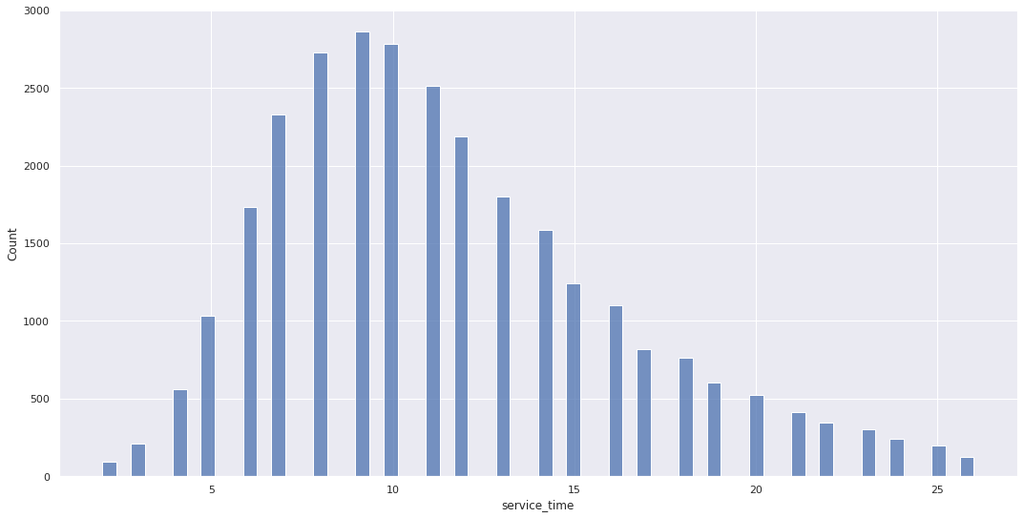

```python
import seaborn as sns

# Det er alltid nyttig å ta en kikk på distribusjonen til labelen vår for å se hva
# vi har med å gjøre.
sns.set(rc={"figure.figsize": (18, 9)})
sns.histplot(deliveries, x="service_time")
```

## Tips og råd på veien

- **Ha det gøy og slipp kreativiteten løs!**
- Python-biblioteker som garantert er lure å bruke:
  - `pandas`: Som forklart ovenfor.
  - `scikit-learn`: Inneholder mer eller mindre all hjelpefunksjonaliteten du trenger for å gjøre maskinlæring, samt implementasjoner av de aller fleste maskinlæringsalgoritmer.
- Maskinlæringsbiblioteker som kan være lure å titte på:
  - `lightgbm`: Bibliotek for å trene såkalte gradient boosting-modeller (som stort sett alltid gir deg de beste resultatene på denne typen problemer). LightGBM er svært raskt å kjøre på CPU, og på grunn av dette er det spesielt fint å bruke hvis du har et komplekst problem med komplekse relasjoner som krever at du tuner hyperparameterne til algoritmen mye.
  - `xgboost`: Den gamle kongen av gradient boosting som pleide å vinne alle Kaggle-konkurransene. Fortsatt et meget godt boosting-bibliotek, men er noe tregere og gir ofte litt dårligere performance enn de andre. Men alltid verdt å prøve!
  - `catboost`: "New kid on the boosting block", gir raskt gode resultater uten noe særlig hyperparametertuning.
  - `tensorflow`: Hvis du føler deg modig!
- Prøv å lage en rask baseline først som du jobber med å slå. Siden vi har flere leveranser på ganske mange kunder i datasettet, og mange leveranser innenfor de samme geografiske områdene, finnes det noen åpenbare kandidater til slike baselines her ...
- Feature engineering er stort sett alltid det viktigste for å få høy ytelse på prediksjonsproblemet. Men husk at hvis du bruker forholdsvis sofistikerte algoritmer, handler dette først og fremst om å bare sørge for at modellen har den informasjonen den trenger for å predikere best mulig på hver rad, fremfor å tweake på nøyaktig hvordan du representerer denne informasjonen. Hvis du bruker enklere algoritmer, må du være mer forsiktig og tenke mer på hvordan features er representert i datasettet. Et godt råd for feature engineering her er uansett å tenke på hvordan du kan bruke informasjon fra andre rader i datasettet på den enkelte observasjon!
- Tenk nøye gjennom hvordan du validerer resultatene dine. Lag alltid et treningssett som du tilpasser modellen på, og et valideringssett som du tester ytelsen på. Hvis du skulle laget denne modellen for Kolonial.no, så ønsker du selvfølgelig at den skal generalisere godt til leveranser frem i tid. Hva må du da tenke på når du skal validere resultatene dine?
- Hos oss evaluerer vi ytelsen til modellen med mean absolute error (MAE). Gjør gjerne det samme hvis du ønsker å benchmarke dine resultater mot våre!